# Figures

Courtney Gale

11/15/2020

```r
#setwd("/Users/Courtney/Documents/Emory_3rd_Semester/CS - Machine Learning/CS534-Final")
#path <- './data/dat.csv'
dat <- read.csv("/Users/Courtney/Documents/Emory_3rd_Semester/CS - Machine Learning/CS534-Final/data/dat.csv")

head(dat)
```

```
##   Health.Service.Area Hospital.County Operating.Certificate.Number Facility.Id
## 1          Western NY        Allegany                       226700          37
## 2          Western NY        Allegany                       226700          37
## 3          Western NY        Allegany                       226700          37
## 4          Western NY        Allegany                       226700          37
## 5          Western NY        Allegany                       226700          37
## 6                                                               NA          NA
##                  Facility.Name   Age.Group Zip Gender  Race         Ethnicity
## 1   Cuba Memorial Hospital Inc 70 or Older 147      F White Not Span/Hispanic
## 2   Cuba Memorial Hospital Inc 70 or Older 147      F White Not Span/Hispanic
## 3   Cuba Memorial Hospital Inc 70 or Older 147      F White Not Span/Hispanic
## 4   Cuba Memorial Hospital Inc    50 to 69 147      F White Not Span/Hispanic
## 5   Cuba Memorial Hospital Inc 70 or Older 147      M White Not Span/Hispanic
## 6 Redacted for Confidentiality 70 or Older          M White  Spanish/Hispanic
##   Length.of.Stay Type.of.Admission                   Patient.Disposition
```

[output cut: 69 more lines]

```r
colnames(dat)
```

```
##  [1] "Health.Service.Area"                 "Hospital.County"
##  [3] "Operating.Certificate.Number"        "Facility.Id"
##  [5] "Facility.Name"                       "Age.Group"
##  [7] "Zip"                                 "Gender"
##  [9] "Race"                                "Ethnicity"
## [11] "Length.of.Stay"                      "Type.of.Admission"
## [13] "Patient.Disposition"                 "Discharge.Year"
## [15] "CCS.Diagnosis.Code"                  "CCS.Diagnosis.Description"
## [17] "CCS.Procedure.Code"                  "CCS.Procedure.Description"
## [19] "APR.DRG.Code"                        "APR.DRG.Description"
## [21] "APR.MDC.Code"                        "APR.MDC.Description"
## [23] "APR.Severity.of.Illness.Code"        "APR.Severity.of.Illness.Description"
## [25] "APR.Risk.of.Mortality"               "APR.Medical.Surgical.Description"
## [27] "Payment.Typology.1"                  "Payment.Typology.2"
## [29] "Payment.Typology.3"                  "Emergency.Department.Indicator"
## [31] "Total.Charges"                       "Total.Costs"
```

```r
# Convert length of stay to numeric
dat[which(dat$Length.of.Stay == '120 +'), 'Length.of.Stay'] <- '121'
dat$Length.of.Stay <- (as.numeric(dat$Length.of.Stay))

# Check result
summary(dat$Length.of.Stay)
```

```
##    Min. 1st Qu.  Median    Mean 3rd Qu.    Max.
##   1.000   2.000   4.000   6.037   7.000 121.000
```

```r
# Create cost per day variable
dat$Cost.per.Day <- dat$Total.Costs / dat$Length.of.Stay
```

# Length of Stay

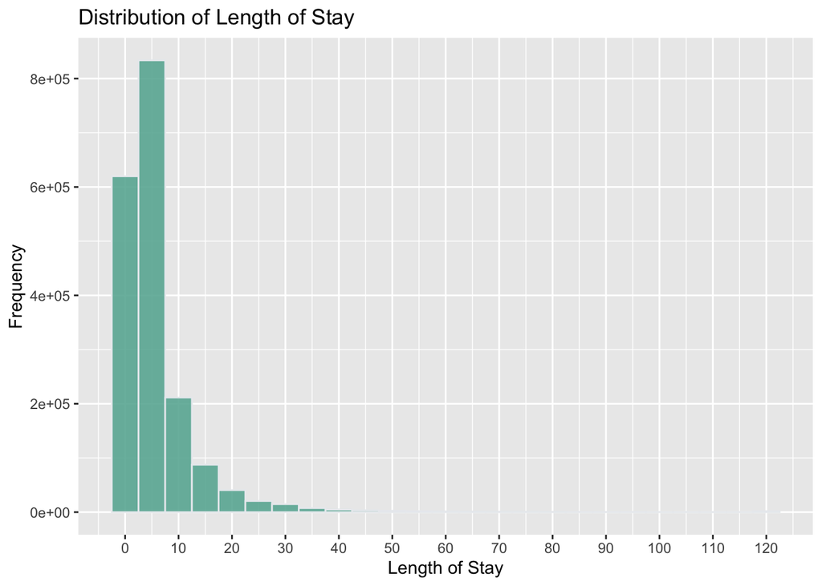

```r
ggplot(dat, aes(x = Length.of.Stay)) + geom_histogram(binwidth = 5, fill="#69b3a2", color="#e9ecef", alpha=0.9) +
  ggtitle("Distribution of Length of Stay") +
  xlab("Length of Stay") +
  ylab("Frequency") +
  scale_x_continuous(breaks = seq(0, 120, by = 10))
```

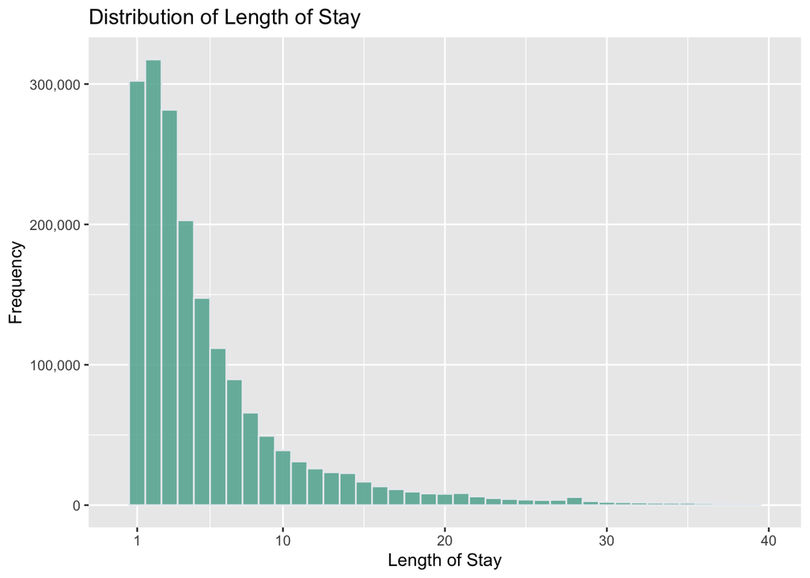

```r
ggplot(dat, aes(x = Length.of.Stay)) + geom_histogram(binwidth = 1, fill="#69b3a2", color="#e9ecef", alpha=0.9) +
  ggtitle("Distribution of Length of Stay") +
  xlab("Length of Stay") +
  ylab("Frequency") +
  scale_x_continuous(breaks = c(1, 10, 20, 30, 40), limits = c(0,40)) +
  scale_y_continuous(labels = scales::comma)
```

### Note y - axis only goes to 30 in order to see the distribution of the boxplot better

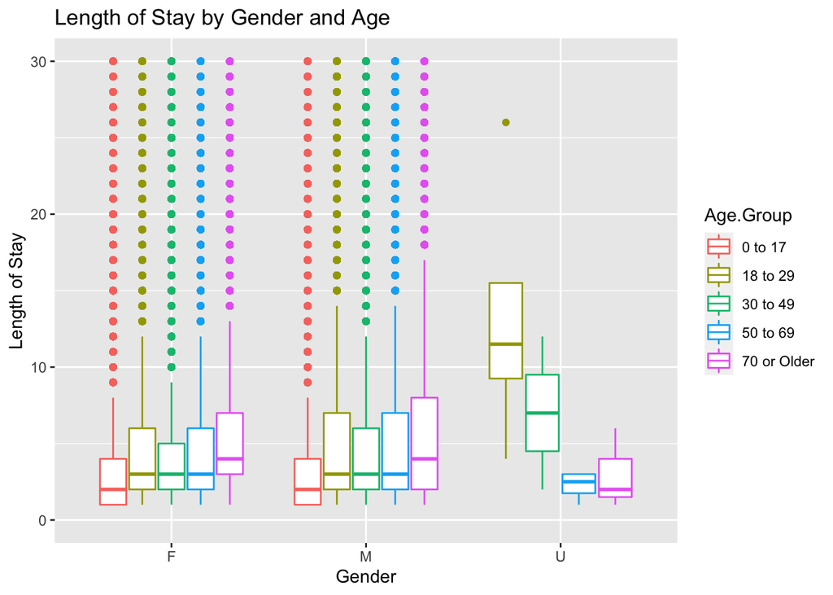

```r
ggplot(dat, aes(x = Gender, y = Length.of.Stay, color = Age.Group)) + geom_boxplot() +
  ggtitle("Length of Stay by Gender and Age") +
  xlab("Gender") +
  ylab("Length of Stay") +
  ylim(0,30)
```

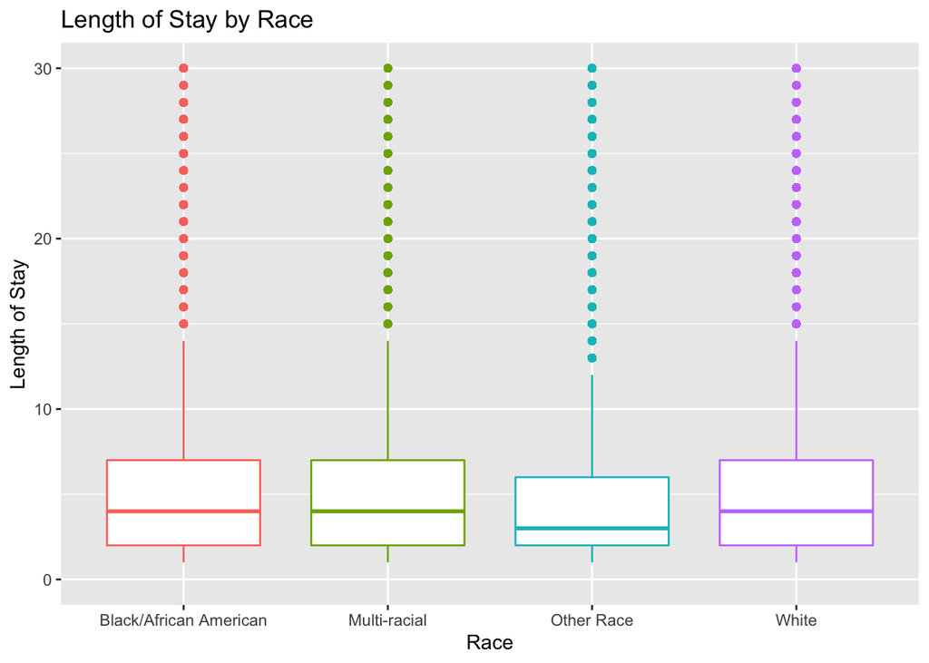

```r
ggplot(dat, aes(x = Race, y = Length.of.Stay, color = Race)) + geom_boxplot() +
  theme(legend.position = "none") +
  ggtitle("Length of Stay by Race") +
  xlab("Race") +
  ylab("Length of Stay") +
  ylim(0,30)
```

0 Pre-MDC or Ungroupable

1 Diseases and Disorders of the Nervous System

2 Diseases and Disorders of the Eye

3 Ear, Nose, Mouth, Throat, and Craniofacial Diseases and Disorders

4 Diseases and Disorders of the Respiratory System

5 Diseases and Disorders of the Circulatory System

6 Diseases and Disorders of the Digestive System

7 Diseases and Disorders of the Hepatobiliary System and Pancreas

8 Diseases and Disorders of the Musculoskeletal System and Connective Tissue

9 Diseases and Disorders of the Skin, Subcutaneous Tissue and Breast

10 Endocrine, Nutritional and Metabolic Diseases and Disorders

11 Diseases and Disorders of the Kidney and Urinary Tract

12 Diseases and Disorders of the Male Reproductive System

13 Diseases and Disorders of the Female Reproductive System

14 Pregnancy, Childbirth and the Puerperium

15 Newborns and Other Neonates with Conditions Originating in the Perinatal Period

16 Diseases and Disorders of Blood, Blood Forming Organs and Immunological Disorders

17 Lymphatic, Hematopoietic, Other Malignancies, Chemotherapy and Radiotherapy

18 Infectious and Parasitic Diseases, Systemic or Unspecified Sites

19 Mental Diseases and Disorders

20 Alcohol/Drug Use and Alcohol/Drug Induced Organic Mental Disorders

21 Poisonings, Toxic Effects, Other Injuries and Other Complications of Treatment

22 Burns

23 Rehabilitation, Aftercare, Other Factors Influencing Health Status and Other Health Service Contacts

24 Human Immunodeficiency Virus (HIV) Infections

25 Multiple Significant Trauma

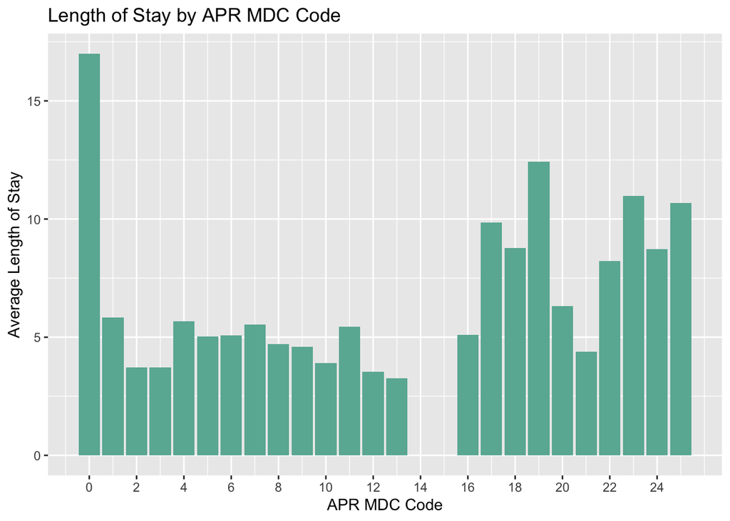

```r
ggplot(aes(x = APR.MDC.Code, y = Length.of.Stay), data = dat) + stat_summary(fun = "mean", geom = "bar",  fill = "#69b3a2") +
  ggtitle("Length of Stay by APR MDC Code") +
  xlab("APR MDC Code") +
  ylab("Average Length of Stay") +
  scale_x_continuous(breaks = seq(0, 25, by = 2))
```

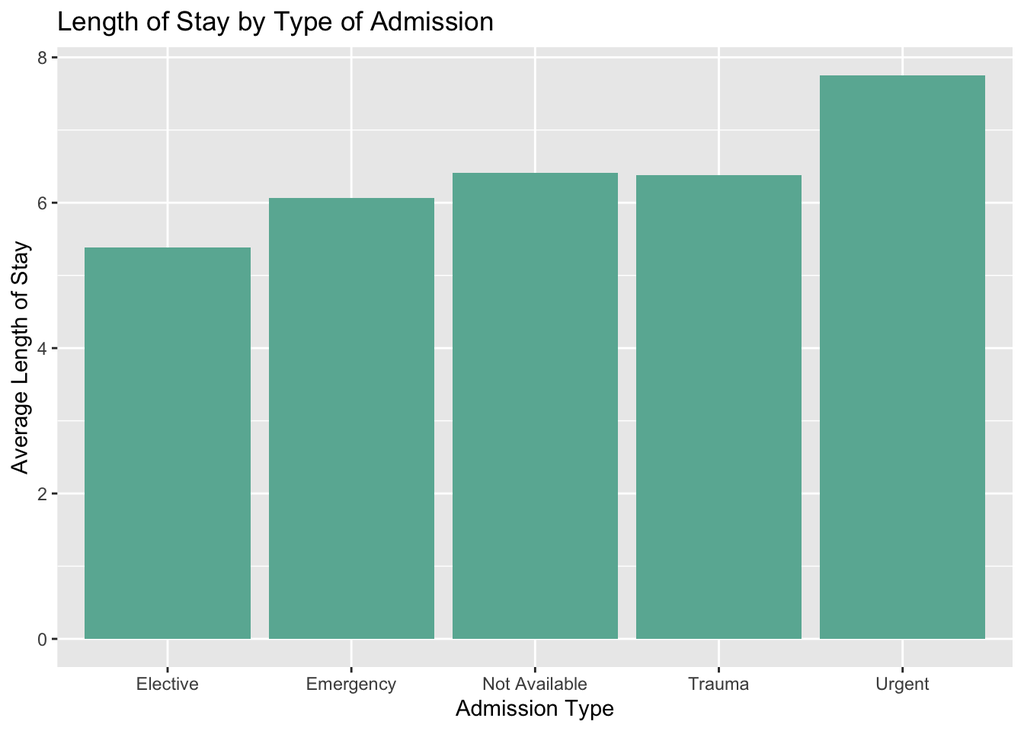

```r
ggplot(aes(x = Type.of.Admission, y = Length.of.Stay), data = dat) + stat_summary(fun = "mean", geom = "bar",  fill = "#69b3a2") +
  ggtitle("Length of Stay by Type of Admission") +
  xlab("Admission Type") +
  ylab("Average Length of Stay")
```

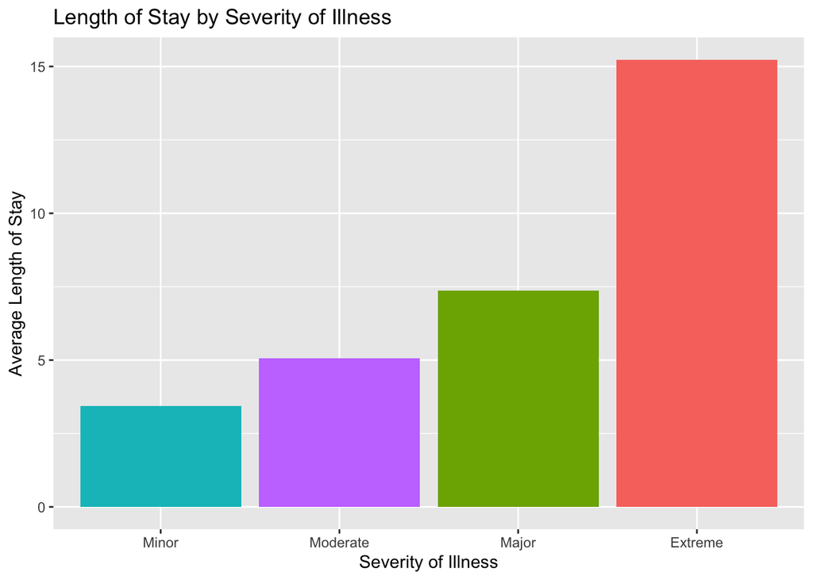

```r
dat$APR.Severity.of.Illness.Description <- ifelse(dat$APR.Severity.of.Illness.Description == "", "NA", dat$APR.Severity.of.Illness.Description)

dat <- dat[!dat$APR.Severity.of.Illness.Description == "NA", ]

ggplot(aes(x = reorder(APR.Severity.of.Illness.Description, Length.of.Stay), y = Length.of.Stay, fill = APR.Severity.of.Illness.Description), data = dat) + stat_summary(fun = "mean", geom = "bar") +
  theme(legend.position = "none") +
  ggtitle("Length of Stay by Severity of Illness") +
  xlab("Severity of Illness") +
  ylab("Average Length of Stay")
```

# Cost per day

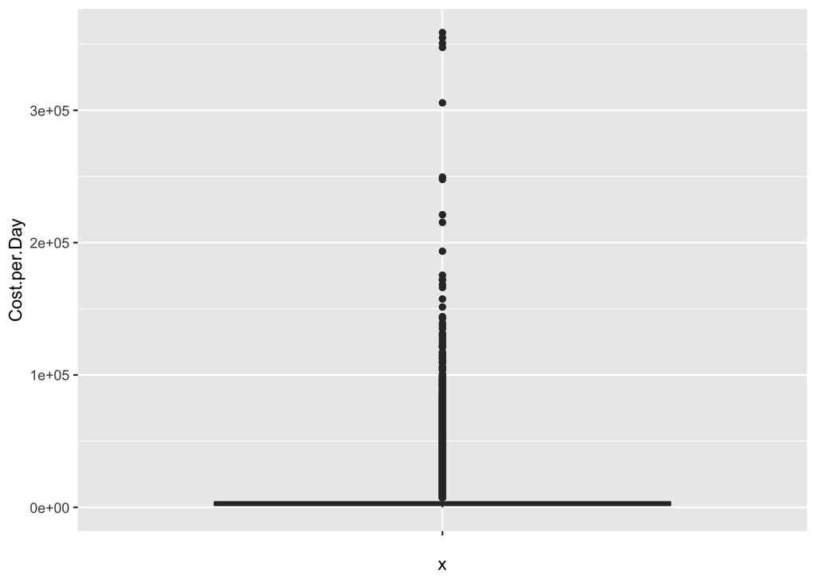

```r
ggplot(dat, aes(x= "", y=Cost.per.Day)) + geom_boxplot()
```

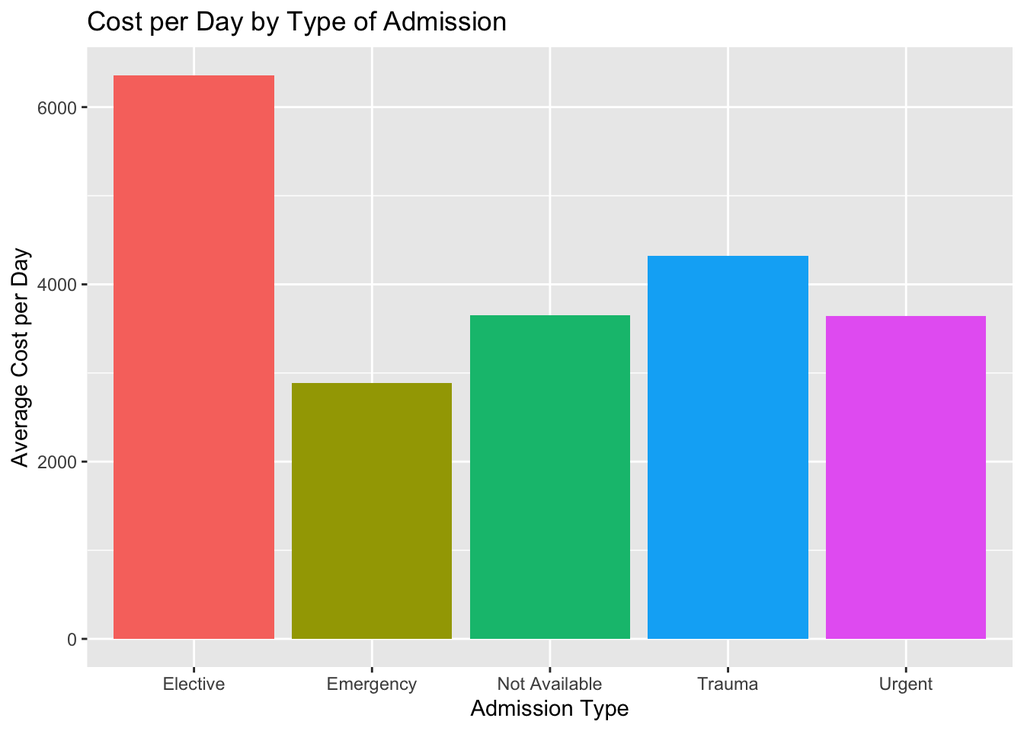

```r
ggplot(aes(x = Type.of.Admission, y = Cost.per.Day, fill = Type.of.Admission), data = dat) + stat_summary(fun = "mean", geom = "bar") +
  theme(legend.position = "none") +
  ggtitle("Cost per Day by Type of Admission") +
  xlab("Admission Type") +
  ylab("Average Cost per Day")
```

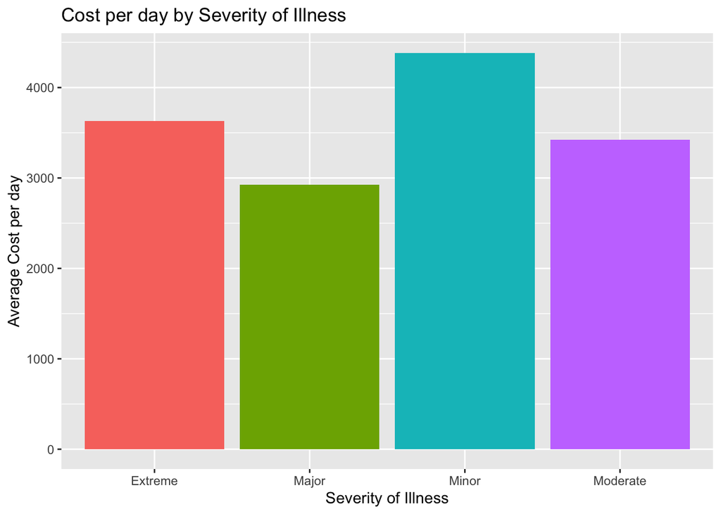

```r
ggplot(aes(x = APR.Severity.of.Illness.Description, y = Cost.per.Day, fill = APR.Severity.of.Illness.Description), data = dat) + stat_summary(fun = "mean", geom = "bar") +
  theme(legend.position = "none") +
  ggtitle("Cost per day by Severity of Illness") +
  xlab("Severity of Illness") +
  ylab("Average Cost per day")
```

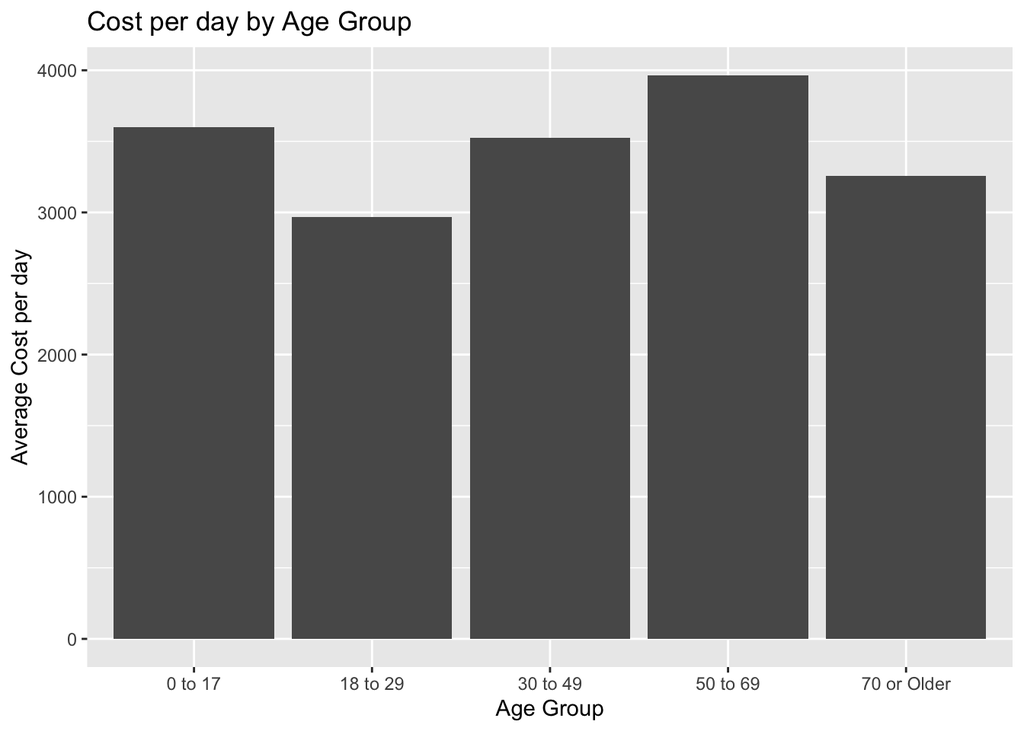

```r
ggplot(aes(x = Age.Group, y = Cost.per.Day), data = dat, fill = Age.Group) + stat_summary(fun = "mean", geom = "bar") +
  theme(legend.position = "none") +
  ggtitle("Cost per day by Age Group") +
  xlab("Age Group") +
  ylab("Average Cost per day")
```